# dapR2 Lab Report 1 - Live R

Tom Booth

08/02/2021

## 0.1 Analysis Strategy

**Points to include, not necessarily in this order:**

- Data checks: Missing data, out of range values, coding of categorical variables
- Personality data: At some point, either here or in model discussion, need to standardized.
- Assumptions:
  - What assumptions need to be tested?
  - What tests/plots are used?
  - How are they evaluated?
  - Could also comment here where the main results will be reported
- Diagnostics:
  - How will you check for influential cases, what are cut-off etc.
- Alpha level
  - Any other adjustments to alpha/ methods of inference

### 0.1.1 Models

The key thing here is to describe the model, the variables within the model, and the information you will use to answer the question

For all questions:

- Models
- What information is used to answer the questions?
  - Significance of F, t, incremental model fit tests etc.
  - Magnitude of the beta coefficients
- This links to back to the question.
- Rationales for decision

**Q1 and Q2** answered with the same model, with reference level changed.

- Outcome, self-rated health
- Predictor location with countryside (or suburb) as reference level.
- Q1 answer by F-test significance and comment on variance explained.
- Q2 answered by the significance of the beta coefficient for the difference between countryside and suburb, with an interpretation of that effect.

**Q3** answered with single lm with all data.

- Outcome, self-rated health
- Predictors, all personality variables. z-scored so as to mean the beta coefficients are standardized and to allow comparison. This is also efficient for the final model which needs an interaction.
- Predictors location and age.
- Question answered by comparison of the beta-coefficients.
- Additional comments could be made on the overall model significance, significance of individual personality variables and variance explained.

**Q4** add the interaction and probe.

- Outcome, self-rated health
- Predictors, everything!
- Focal test is the significance of the interaction term fro N and C
- Support for healthy-N is a buffering interaction assessed via the direction of the coefficients (-N, +C, + N*C), and a simple slopes plot.

## 0.2 Results

Report the above.

### 0.2.1 Descriptives

```r
library(tidyverse)
library(sjPlot)
tib <- read_csv("C:/Work/Teaching/psychstats/assignments/dapr2/dapr2_report.csv", col_types = "fdfdddddd")
```

### 0.2.2 Q1 and Q2

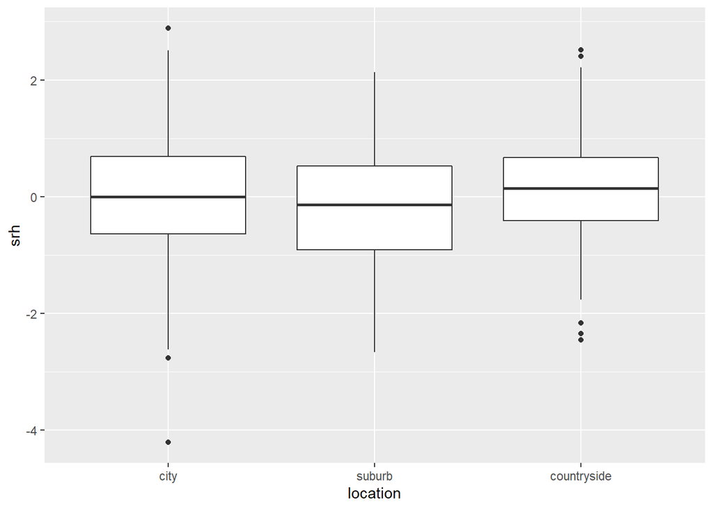

Figure 1:  
*Hello, is it a boxplot you are looking for*

```r
tib %>%
  ggplot(., aes(x=location, y=srh)) +
  geom_boxplot()
```

As you can see in **Figure1**

```r
tib %>%
  group_by(location) %>%
  summarise(
    mean = mean(srh),
    sd = sd(srh)
  )
```

```
## # A tibble: 3 x 3
##   location       mean    sd
##   <fct>         <dbl> <dbl>
## 1 city         0.0197 0.997
## 2 suburb      -0.199  1.02
## 3 countryside  0.114  0.974
```

```r
levels(tib$location)
```

```
## [1] "city"        "suburb"      "countryside"
```

```r
contrasts(tib$location) <- contr.treatment(3, 2)
m1 <- lm(srh ~ location, data = tib)
summary(m1)
```

```
##
## Call:
## lm(formula = srh ~ location, data = tib)
##
## Residuals:
##     Min      1Q  Median      3Q     Max
## -4.2274 -0.6468  0.0112  0.6567  2.8648
##
## Coefficients:
##             Estimate Std. Error t value Pr(>|t|)
## (Intercept)  -0.1992     0.0914  -2.180   0.0296 *
## location1     0.2189     0.1015   2.157   0.0313 *
## location3     0.3127     0.1290   2.425   0.0156 *
## ---
## Signif. codes:  0 '***' 0.001 '**' 0.01 '*' 0.05 '.' 0.1 ' ' 1
##
## Residual standard error: 0.997 on 747 degrees of freedom
## Multiple R-squared:  0.008635,   Adjusted R-squared:  0.005981
## F-statistic: 3.253 on 2 and 747 DF,  p-value: 0.03919
```

(*F*(2,747)=3.253, *p*<.05 )

```r
tab_model(m1, show.se = T, show.stat = T, string.se = "Bob",
          pred.labels = c("Intercept", "Location (City)", "Location (Countryside)"))
```

|  | srh |  |  |  |  |
| --- | --- | --- | --- | --- | --- |
| Predictors | Estimates | Bob | CI | Statistic | p |
| Intercept | -0.20 | 0.09 | -0.38 – -0.02 | -2.18 | **0.030** |
| Location (City) | 0.22 | 0.10 | 0.02 – 0.42 | 2.16 | **0.031** |
| Location (Countryside) | 0.31 | 0.13 | 0.06 – 0.57 | 2.42 | **0.016** |
| Observations | 750 |  |  |  |  |
| R<sup>2</sup> / R<sup>2</sup> adjusted | 0.009 / 0.006 |  |  |  |  |

### 0.2.3 Q3

```r
m2 <- lm(srh ~ age + location + scale(N) + scale(E) + scale(O) + scale(A) + scale(C), data = tib)
summary(m2)
```

```
##
## Call:
## lm(formula = srh ~ age + location + scale(N) + scale(E) + scale(O) +
##     scale(A) + scale(C), data = tib)
##
## Residuals:
##      Min       1Q   Median       3Q      Max
## -2.92676 -0.52891 -0.02701  0.54740  2.61640
##
## Coefficients:
##              Estimate Std. Error t value Pr(>|t|)
## (Intercept)  1.559156   0.296408   5.260 1.89e-07 ***
## age         -0.041614   0.006850  -6.075 1.99e-09 ***
## location1    0.197385   0.082648   2.388  0.01718 *
## location3    0.318539   0.106942   2.979  0.00299 **
## scale(N)    -0.309432   0.033464  -9.247  < 2e-16 ***
## scale(E)     0.180810   0.035203   5.136 3.59e-07 ***
## scale(O)    -0.005467   0.034529  -0.158  0.87424
## scale(A)     0.196579   0.031703   6.201 9.33e-10 ***
## scale(C)     0.211785   0.032555   6.505 1.43e-10 ***
## ---
## Signif. codes:  0 '***' 0.001 '**' 0.01 '*' 0.05 '.' 0.1 ' ' 1
##
## Residual standard error: 0.8004 on 741 degrees of freedom
## Multiple R-squared:  0.3662, Adjusted R-squared:  0.3594
## F-statistic: 53.52 on 8 and 741 DF,  p-value: < 2.2e-16
```

### 0.2.4 Q4

```r
m3 <- lm(srh ~ age + location + scale(N) + scale(E) + scale(O) + scale(A) + scale(C) + scale(N)*scale(C), data = tib)
summary(m3)
```

```
##
## Call:
## lm(formula = srh ~ age + location + scale(N) + scale(E) + scale(O) +
##     scale(A) + scale(C) + scale(N) * scale(C), data = tib)
##
## Residuals:
##      Min       1Q   Median       3Q      Max
## -2.60838 -0.50797 -0.02135  0.51686  2.65637
##
## Coefficients:
##                    Estimate Std. Error t value Pr(>|t|)
## (Intercept)        1.661890   0.294769   5.638 2.45e-08 ***
## age               -0.043097   0.006796  -6.341 3.96e-10 ***
## location1          0.199337   0.081865   2.435 0.015129 *
## location3          0.319184   0.105927   3.013 0.002673 **
## scale(N)          -0.307669   0.033149  -9.281  < 2e-16 ***
## scale(E)           0.179461   0.034871   5.146 3.40e-07 ***
## scale(O)          -0.001405   0.034217  -0.041 0.967268
## scale(A)           0.198831   0.031407   6.331 4.23e-10 ***
## scale(C)           0.204715   0.032297   6.339 4.03e-10 ***
## scale(N):scale(C)  0.109919   0.028127   3.908 0.000102 ***
## ---
## Signif. codes:  0 '***' 0.001 '**' 0.01 '*' 0.05 '.' 0.1 ' ' 1
##
## Residual standard error: 0.7928 on 740 degrees of freedom
## Multiple R-squared:  0.379,  Adjusted R-squared:  0.3715
## F-statistic: 50.19 on 9 and 740 DF,  p-value: < 2.2e-16
```

```r
anova(m2,m3)
```

```
## Analysis of Variance Table
##
## Model 1: srh ~ age + location + scale(N) + scale(E) + scale(O) + scale(A) +
##     scale(C)
## Model 2: srh ~ age + location + scale(N) + scale(E) + scale(O) + scale(A) +
##     scale(C) + scale(N) * scale(C)
##   Res.Df    RSS Df Sum of Sq      F    Pr(>F)
## 1    741 474.69
## 2    740 465.09  1    9.5988 15.273 0.0001016 ***
## ---
## Signif. codes:  0 '***' 0.001 '**' 0.01 '*' 0.05 '.' 0.1 ' ' 1
```

```r
library(interactions)
```

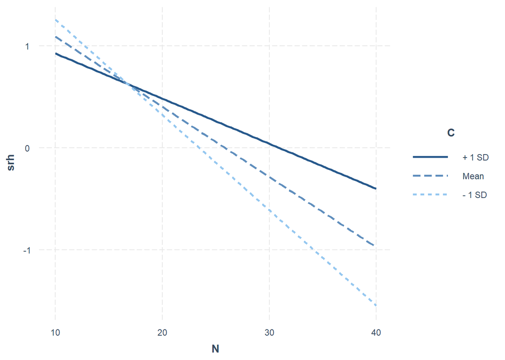

```r
interact_plot(m3, pred = N, modx = C, data = tib)
```

Include: - Tables - Figures - Interaction plot - Simple slopes or regions of significance plot - Comment on whether the interaction is buffering or not.

## 0.3 Discussion

Essentially 1 - 2 sentences per model/question. Key points: - Don’t repeat results verbatim - Comment on all questions - Be accurate with respect to the results shown

## 0.4 General Writing

## 0.5 Assumption/Diagnostic Appendix

Label!!!!